# CH08P43 Student t Test One Sample

crl

January 21, 2018

```r
knitr::opts_chunk$set(echo = TRUE)
```

# QCI Six Sigma Primer

## Student t Test One Sample

### Read More

Where the population variance is not known, a Student’s t-test is used to compare means.  
The One Sample Student t Test is used to compare a sample mean to a target value.

[Student t Test Wikipedia](https://en.wikipedia.org/wiki/Student%27s_t-test#One-sample_t-test)

[One Sample Student t Test Wikipedia](https://en.wikipedia.org/wiki/Student%27s_t-test#One-sample_t-test)

The One Sample t-Test compares a sample mean to a known or hypothesized mean. [Example here](https://www.statmethods.net/stats/ttest.html)

[Read more (Berkeley)](https://statistics.berkeley.edu/computing/r-t-tests)

[Presentation](https://docs.google.com/presentation/d/e/2PACX-1vQHzYZ-PB8lu0ViBuok34ltHeuz4tihqMDNHvRccPIa6bDfZXEvzys3aoBWe7quW6wkEU07tRto4-L8/pub?start=false&loop=false&delayms=10000)

# Analysis

## Load Packages

```r
library(dplyr)
```

## Primer Example with summarized data provided

```r
# historical mean yield
mu0 <- 880

# sample data
ssize <- 25
mean_yield <- 900  # sample mean (given in text)
sstdev <- 20  # sample standard deviation (given in text)
sstderr <- sstdev/sqrt(ssize)  # standard error of the mean

# calculated value of Student t
tcalc <- (mean_yield - mu0)/(sstderr)

alpha <- 0.05

# for a two-sided hypothesis test use alpha/2
tcrit_lower = round(qt(p = alpha/2, df = ssize - 1), 3)
tcrit_upper = round(qt(p = (1 - alpha/2), df = ssize - 1), 3)

if (tcalc < tcrit_lower | tcalc > tcrit_upper){
  cat("t calculated is greater than abs(t critical) therefore REJECT H0")
} else {
  cat("t calculated is less than abs(t critical) therefore FAIL TO REJECT H0")
}
```

```
## t calculated is greater than abs(t critical) therefore REJECT H0
```

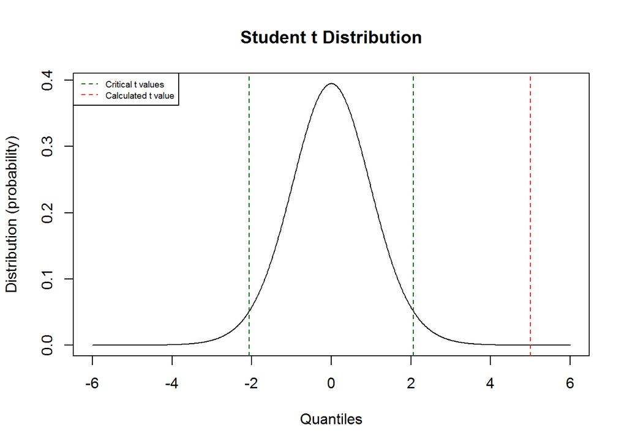

```r
# create a plot showing the outcome
xq <- seq(-6, 6, by = 0.01)  # the 'quantiles' (x values)
xp <- dt(x = xq, df = ssize - 1)  # the distribution (y values)

plot(x = xq, y = xp, type = 'l',
     xlab = 'Quantiles', ylab = 'Distribution (probability)')
title(main = 'Student t Distribution')

# plots the critical t value based on degrees of freedom (df = sample size - 1)
abline(v = tcalc, lty = 2, col = 'red')

# plots the calculate t value
abline(v = c(tcrit_lower, tcrit_upper), lty = 2, col = 'darkgreen')

# add a legend
legend("topleft", legend=c("Critical t values", "Calculated t value"),
       col=c("darkgreen", "red"), lty = 2, cex=0.6)
```

## Example with simulated data

Why create simulated data? Most experiments result in raw data to be used in the analysis. We create simulated data for this example to show how the analysis works with raw (unsummarized) data.

### Simulate data

We use the ‘set.seed’ function affects the random number generation. We use it within a loop for reproducability.  
The loop runs through each seed, creates a random normal sample with specified mean and standard deviation. The sample mean and sample standard deviation are calculated for that iteration and stored in a dataframe.  
When the loop is finished the absolute distance of each sample statistic from the desired value is calculated and summed. We then look for the minimum value of this sum (deviation).

```r
mu_x0 <- 900
sd_x0 <- 20

# empty dataframe to collect results
rslt <- data.frame(i = as.numeric(), dtot = as.numeric())

# loop through seeds for RNG
for (loop_i in 1:1000){

  set.seed(loop_i); x <- rnorm(25, mean = mu_x0, sd = sd_x0);
  mx <- mean(x)
  sx <- sd(x)

  diff_m <- abs(mx - mu_x0)
  diff_s <- abs(sx - sd_x0)

  diff_tot <- diff_m + diff_s

  rslt[loop_i, 'i'] <- loop_i
  rslt[loop_i, 'dtot'] <- diff_tot

}
```

```r
rslt <- rslt %>% mutate(absdif = abs(dtot - 0)) # somewhat redundant, but can use if diff target <> 0
rslt <- arrange(rslt, absdif)
```

Plot the result of the data simulation.

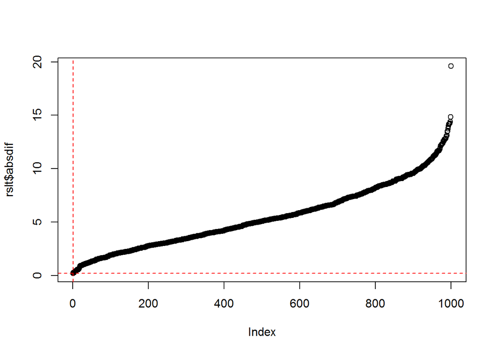

```r
plot(rslt$absdif)
abline(h = rslt[1, 'absdif'], lty = 2, col = 'red')
abline(v = 1, lty = 2, col = 'red')
```

Look at simulated differences.

```r
head(rslt)
```

```
##     i      dtot    absdif
## 1 575 0.1967360 0.1967360
## 2 992 0.2766274 0.2766274
## 3 322 0.2853377 0.2853377
## 4 834 0.2877343 0.2877343
## 5 641 0.3302697 0.3302697
## 6 805 0.3643498 0.3643498
```

Which seed to use? The one that minimizes the difference from the desired sample statistics.

```r
cat("Value fed to set.seed = ", rslt[1,1])
```

```
## Value fed to set.seed =  575
```

Get the simulated data for the example.

```r
set.seed(rslt[1,1]); samplex = rnorm(25, mean = mu_x0, sd = sd_x0); mean(x); sd(x)
```

```
## [1] 895.6131
```

```
## [1] 19.00236
```

```r
cat(paste('simulated mean', round(mean(x), 2), '\n'))
```

[output not shown]

```r
cat(paste('simulated sd', round(sd(x), 3)))
```

[output not shown]

### Now we perform the one sample t test in R using the simulated sample data.

The critical values (two-sided) of t remain the same as above.  
Look at both the p-value and the confidence interval of the sample mean.

```r
t.test(samplex, mu = 880, alternative = "two.sided") # H0: mu = 880
```

```
##
##  One Sample t-test
##
## data:  samplex
## t = 4.9508, df = 24, p-value = 4.709e-05
## alternative hypothesis: true mean is not equal to 880
## 95 percent confidence interval:
##  891.5550 908.0764
## sample estimates:
## mean of x
##  899.8157
```